# Milestone Report

arbkz

18/08/2019

# Introduction

The goal of this report is to display some basic statistics about the datasets and outline plans to create a prediction algorithm. This analysis will make extensive use of the tidy_text library to process the data, which wraps various other text processing libraries like quanteda and tm.

The data files are read and randomly sampled then partitioned into training, testing and validation sets. The training sets are combined into a single data frame and then tokenised into words, bigrams and trigrams.

Various summary statistics are then calculated and plotted. Finally the Bigrams are plotted as a directional graph to show word connections

## Data

The dataset used in this project is provided by Swiftkey and Coursera and can be found [here](https://d396qusza40orc.cloudfront.net/dsscapstone/dataset/Coursera-SwiftKey.zip).  
and contains text in German, Russian, Swedish and English.

The initial analysis will focus on the English data files: *en_US.blogs.txt*, *en_US.news.txt*, and *en_US.twitter.txt*

## Experimental Design

We sample 44,000 lines of text at random from the three files, taking approximately the same number of samples from each file. We then split this into training, testing and validation sets (60%/20%/20%).

We use will the training set for the expolaratory analysis and model training.

Once we build our model, the testing set will be used ofor model selection and the validation set will be used to estimate out of sample error rate.

# Exploratory Data Analyis

The steps in our EDA are as follows

```r
head(training_data)
```

```
## # A tibble: 6 x 2
##   random_lines                                                     data_set
##   <chr>                                                            <chr>
## 1 And that's just the holding space.                               blogs
## 2 (Now I'm a little disturbed that he's okay with my dying as lon… blogs
## 3 But I do like semen. With the salt spray on our faces, and the … blogs
## 4 "As for my November update, I discovered that I've mostly been … blogs
## 5 What tarot has told me so far is: Something or someone lured Is… blogs
## 6 Title of Manuscript: Grim Reaper's Novice                        blogs
```

### Tokenization

“A token is a meaningful unit of text, most often a word, that we are interested in using for further analysis, and tokenization is the process of splitting text into tokens.” (Text Mining with R, 1.3, Silge and Robinson)

We will use tidytext’s unnest_tokens() function to split the text into words, bigrams and trigrams.  
This will:  
* strip all punctuation * convert everything to lowercase * split the text into words/ngrams/sentences etc.

We tokenize each of the texts separately and then merge the results into a single data frame.

### Word/Bigram/Trigram Frequency

For each word (or ngram) we will count the number of times each word occurs in the text then divide this by the total number of words in the text to find the term frequency.

We then plot this as a histogram to understand variation in the frequencies of words and word pairs across the different data sources.

We then plot the top 10 words bigrams and trigrams from each data sets.

We find that the words and ngrams have a long tail distribution where there are a few words/ngrams that occur frequently and many words/ngrams that occur very rarely.

```
## # A tibble: 6 x 2
##   data_set word
##   <chr>    <chr>
## 1 blogs    and
## 2 blogs    that's
## 3 blogs    just
## 4 blogs    the
## 5 blogs    holding
## 6 blogs    space
```

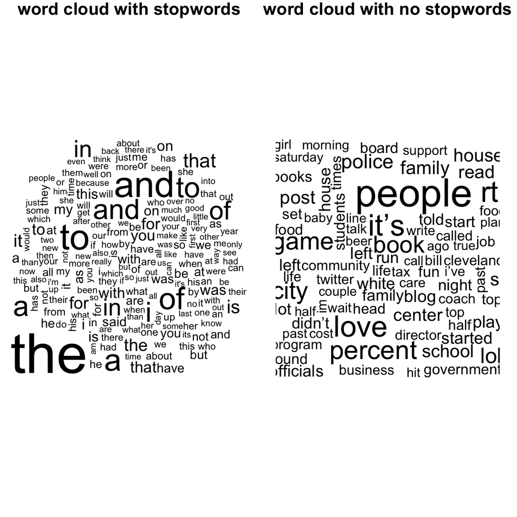

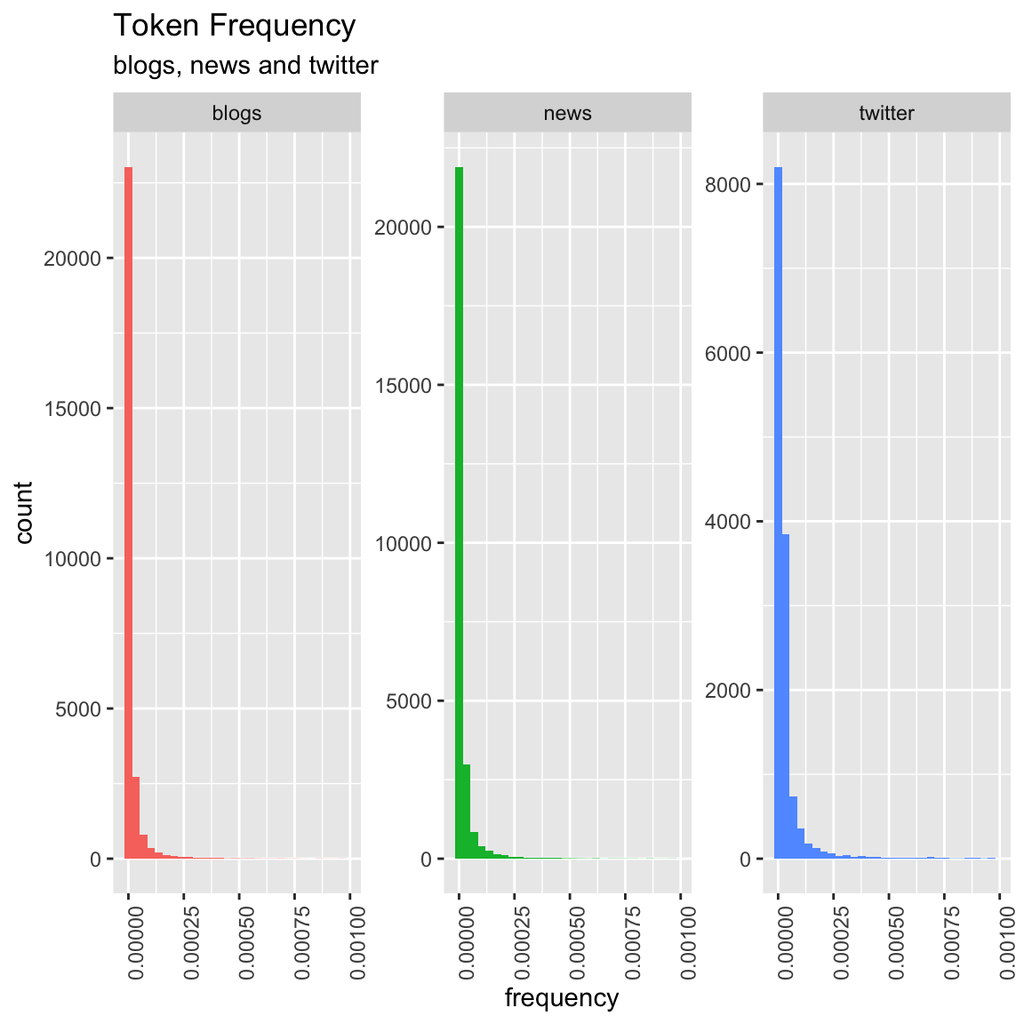

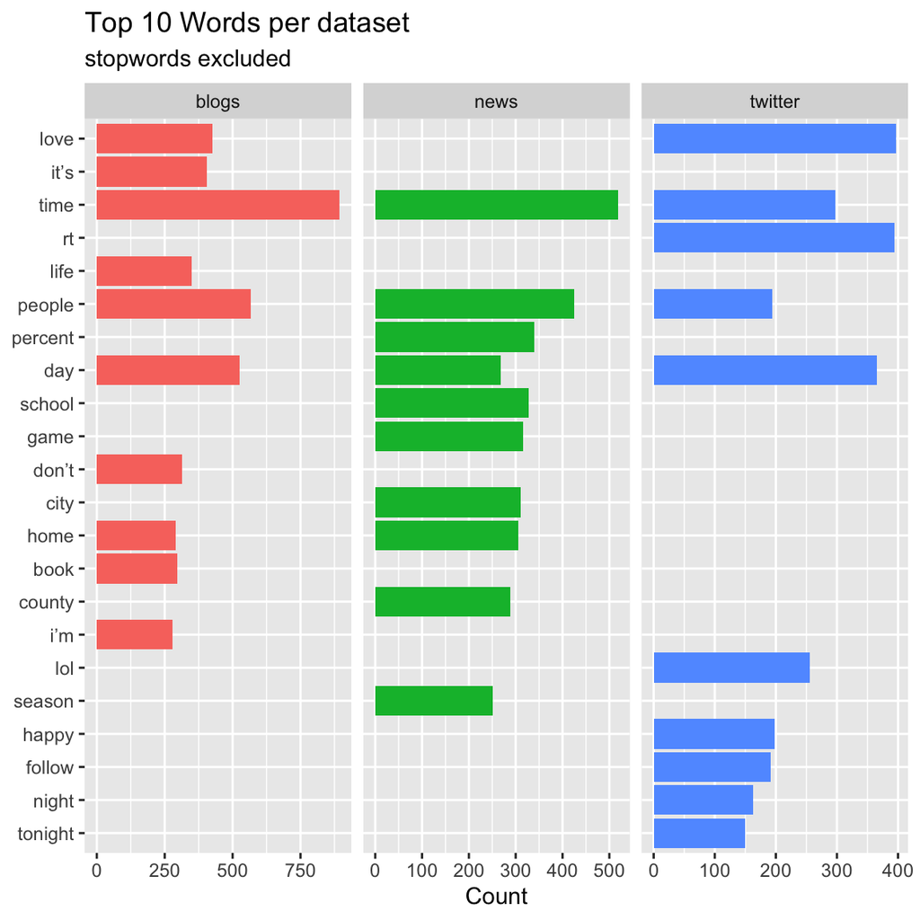

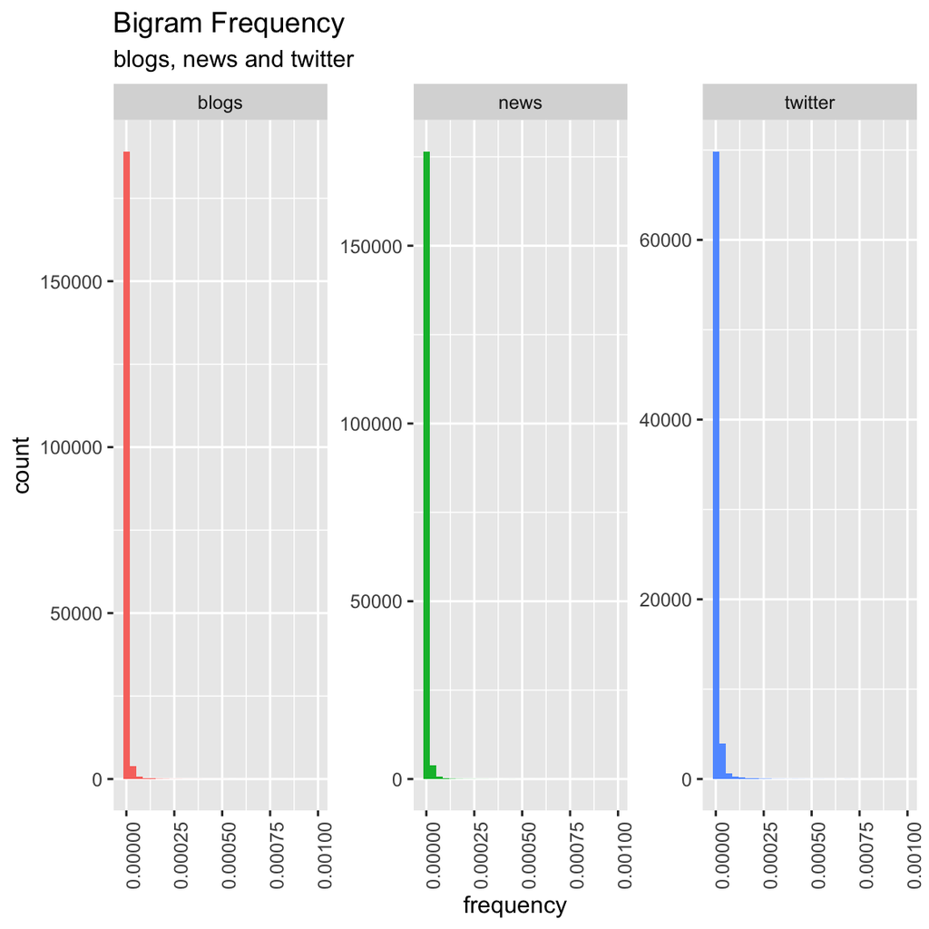

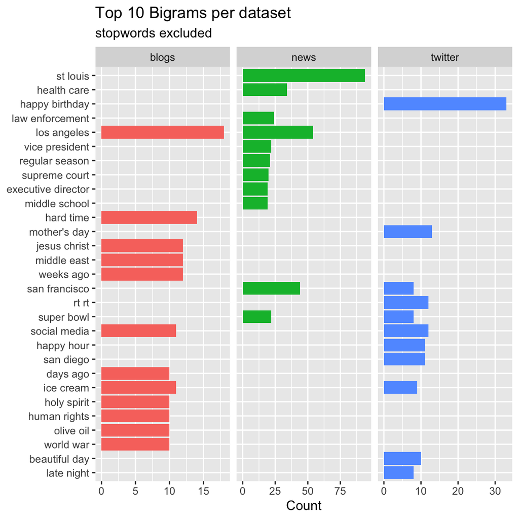

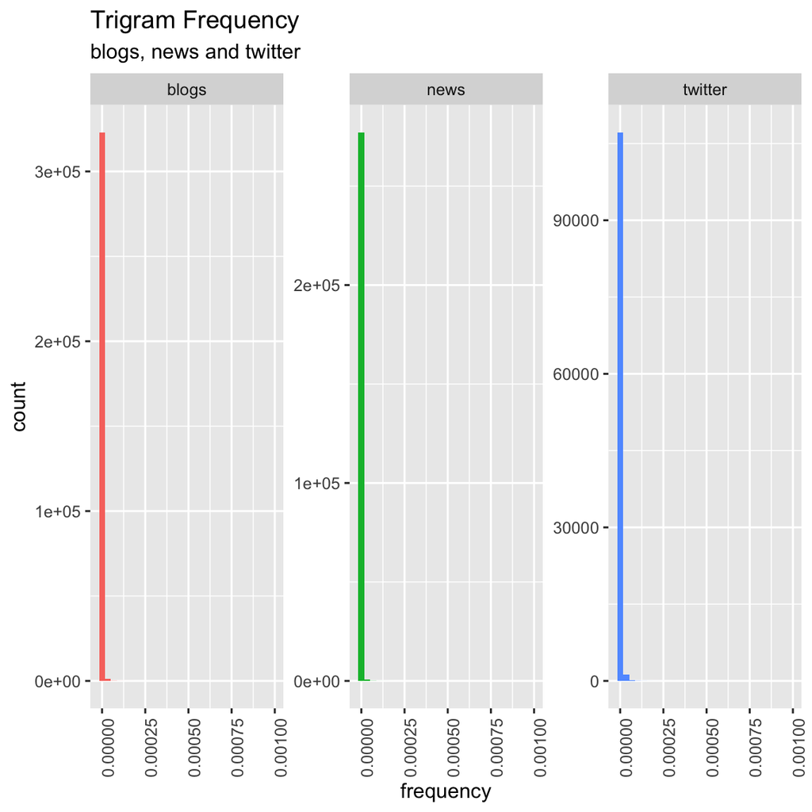

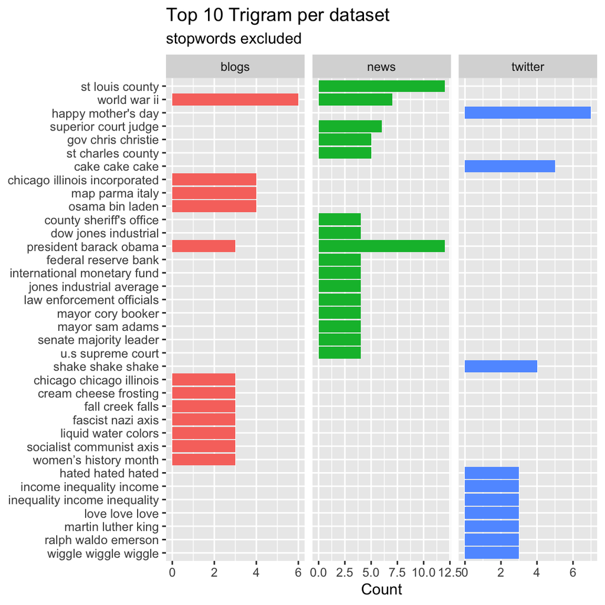

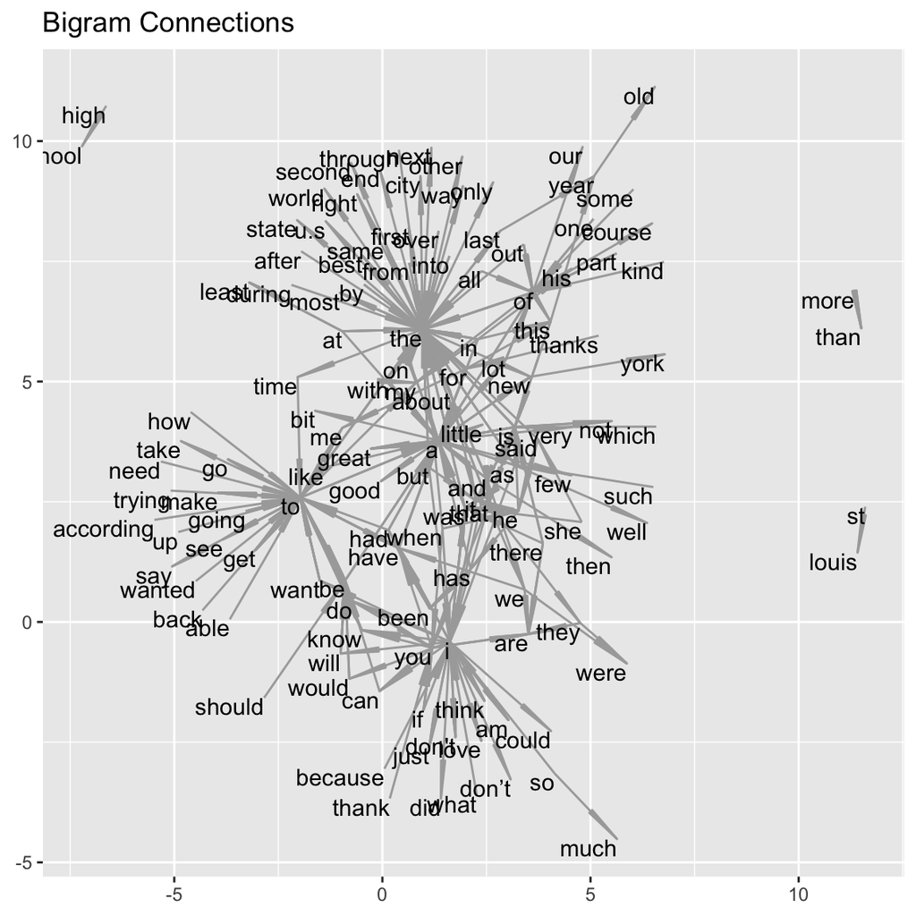

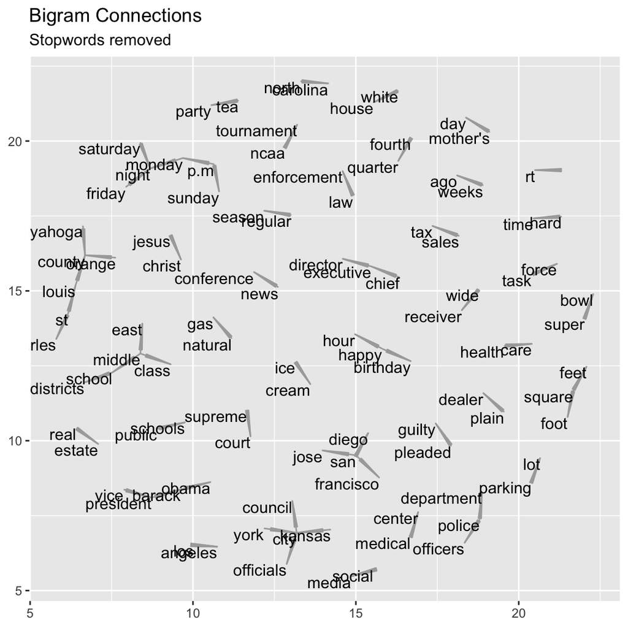

```
## # A tibble: 3 x 5
##   filename   char_count word_count$word_… bigram_count$bi… trigram_count$t…
##   <fct>           <dbl>             <int>            <int>            <int>
## 1 ./data/fi…  206824505             27745           194617           324320
## 2 ./data/fi…  203223159             27157           181593           278073
## 3 ./data/fi…  162096031             14064            75263           108608
```

# Findings

Findings so far:

- Twitter data has on average 1/3 of the number of words per line compared to news (data) and blogs so we may need to combine the three datasets in a more balanced way (to prevent bias) read more lines from twitter
- More data cleaning is required especially the twitter data where there are many words that include special characters and usernames and hastags and repeated words forming bigrams/trigrams
- profanity filtering is hard :-)
- Need a better regex to deal with special characters and non english words

## Plans going forward

- More data cleaning, especially the twitter data (improved regex, better profanity list, remove words with special characters indicating foreign language)
- Use the cleaned data to build our ngram model that can predict the next word based on previous n words
- Incorporate this model into a simple shiny app
- Find a good trade off between performance and accuracy so we can achieve decent performance and stay within the free account limits (1GB RAM)
- Investigate smoothing and backoff to help our predictor deal with words that are not in the corpus

## References

[Source on github](https://github.com/arbkz/Data-Science-Capstone/blob/master/milestone_report.Rmd)

Bradley Boehmke, *UC Business Analytics R Programming Guide, Text Mining: Creating Tidy Text* https://uc-r.github.io/tidy_text

2019, Julia Silge and David Robinson, *Text Mining with R* https://www.tidytextmining.com/tidytext.html